### IMPORTING LIBRARIES

```python
import numpy as np
import pandas as pd
from matplotlib import pyplot as plt
import seaborn as sns
```

### UNDERSTANDING THE DATA

```python
data=pd.read_csv("C:/Users/SRAVYA/Downloads/Literacy Data 2011.csv")
```

```python
data.head()
```

|  | Unnamed: 0 | District | State | Literacy |
| --- | --- | --- | --- | --- |
| 0 | 1 | Thane | Maharashtra | 84.53 |
| 1 | 2 | North Twenty Four Parganas | West Bengal | 84.06 |
| 2 | 3 | Bangalore | Karnataka | 87.67 |
| 3 | 4 | Pune | Maharashtra | 86.15 |
| 4 | 5 | Mumbai Suburban | Maharashtra | 89.91 |

```python
data.tail()
```

|  | Unnamed: 0 | District | State | Literacy |
| --- | --- | --- | --- | --- |
| 635 | 636 | Nicobars | Andaman And Nicobar Islands | 78.06 |
| 636 | 637 | Upper Siang | Arunachal Pradesh | 59.99 |
| 637 | 638 | Lahul and Spiti | Himachal Pradesh | 76.81 |
| 638 | 639 | Anjaw | Arunachal Pradesh | 56.46 |
| 639 | 640 | Dibang Valley | Arunachal Pradesh | 64.10 |

```python
data.shape
```

```
(640, 4)
```

```python
data.describe()
```

|  | Unnamed: 0 | Literacy |
| --- | --- | --- |
| count | 640.000000 | 640.000000 |
| mean | 320.500000 | 72.308422 |
| std | 184.896367 | 10.488816 |
| min | 1.000000 | 36.100000 |
| 25% | 160.750000 | 65.095000 |
| 50% | 320.500000 | 72.170000 |
| 75% | 480.250000 | 79.962500 |
| max | 640.000000 | 97.910000 |

```python
data.info()
```

```
<class 'pandas.core.frame.DataFrame'>
RangeIndex: 640 entries, 0 to 639
Data columns (total 4 columns):
 #   Column      Non-Null Count  Dtype
---  ------      --------------  -----
 0   Unnamed: 0  640 non-null    int64
 1   District    640 non-null    object
 2   State       640 non-null    object
 3   Literacy    640 non-null    float64
dtypes: float64(1), int64(1), object(2)
memory usage: 20.1+ KB
```

```python
data['State'].value_counts()
```

```
 Uttar Pradesh                  71
 Madhya Pradesh                 50
 Bihar                          38
 Maharashtra                    35
 Rajasthan                      33
 Tamil Nadu                     32
 Karnataka                      30
 Orissa                         30
 Assam                          27
 Gujarat                        26
 Jharkhand                      24
 Andhra Pradesh                 23
 Jammu and Kashmir              22
 Haryana                        21
 Punjab                         20
 West Bengal                    19
 Chhattisgarh                   18
 Arunachal Pradesh              16
 Kerala                         14
 Uttarakhand                    13
 Himachal Pradesh               12
 Nagaland                       11
 Manipur                         9
 Delhi                           9
 Mizoram                         8
 Meghalaya                       7
 Puducherry                      4
 Sikkim                          4
 Tripura                         4
 Andaman And Nicobar Islands     3
 Goa                             2
 Daman and Diu                   2
 Dadra and Nagar Haveli          1
 Lakshadweep                     1
 Chandigarh                      1
Name: State, dtype: int64
```

```python
data["State"].value_counts()[0:10]
```

```
 Uttar Pradesh     71
 Madhya Pradesh    50
 Bihar             38
 Maharashtra       35
 Rajasthan         33
 Tamil Nadu        32
 Karnataka         30
 Orissa            30
 Assam             27
 Gujarat           26
Name: State, dtype: int64
```

```python
data=data.sort_values(by=['Literacy'],ascending=False)
data
```

|  | Unnamed: 0 | District | State | Literacy |
| --- | --- | --- | --- | --- |
| 625 | 626 | Serchhip | Mizoram | 97.91 |
| 557 | 558 | Aizawl | Mizoram | 97.89 |
| 634 | 635 | Mahe | Puducherry | 97.87 |
| 233 | 234 | Kottayam | Kerala | 97.21 |
| 397 | 398 | Pathanamthitta | Kerala | 96.55 |
| ... | ... | ... | ... | ... |
| 391 | 392 | Nabarangapur | Orissa | 46.43 |
| 439 | 440 | Jhabua | Madhya Pradesh | 43.30 |
| 539 | 540 | Dantewada | Chhattisgarh | 42.12 |
| 580 | 581 | Bijapur | Chhattisgarh | 40.86 |
| 497 | 498 | Alirajpur | Madhya Pradesh | 36.10 |

640 rows × 4 columns

```python
Data=data.head(10)
Data
```

|  | Unnamed: 0 | District | State | Literacy |
| --- | --- | --- | --- | --- |
| 625 | 626 | Serchhip | Mizoram | 97.91 |
| 557 | 558 | Aizawl | Mizoram | 97.89 |
| 634 | 635 | Mahe | Puducherry | 97.87 |
| 233 | 234 | Kottayam | Kerala | 97.21 |
| 397 | 398 | Pathanamthitta | Kerala | 96.55 |
| 609 | 610 | Champhai | Mizoram | 95.91 |
| 103 | 104 | Ernakulam | Kerala | 95.89 |
| 214 | 215 | Alappuzha | Kerala | 95.72 |
| 169 | 170 | Kannur | Kerala | 95.10 |
| 109 | 110 | Thrissur | Kerala | 95.08 |

```python
Data2=data.head(20)
Data2
```

|  | Unnamed: 0 | District | State | Literacy |
| --- | --- | --- | --- | --- |
| 625 | 626 | Serchhip | Mizoram | 97.91 |
| 557 | 558 | Aizawl | Mizoram | 97.89 |
| 634 | 635 | Mahe | Puducherry | 97.87 |
| 233 | 234 | Kottayam | Kerala | 97.21 |
| 397 | 398 | Pathanamthitta | Kerala | 96.55 |
| 609 | 610 | Champhai | Mizoram | 95.91 |
| 103 | 104 | Ernakulam | Kerala | 95.89 |
| 214 | 215 | Alappuzha | Kerala | 95.72 |
| 169 | 170 | Kannur | Kerala | 95.10 |
| 109 | 110 | Thrissur | Kerala | 95.08 |
| 113 | 114 | Kozhikode | Kerala | 95.08 |
| 152 | 153 | Kollam | Kerala | 94.09 |
| 49 | 50 | Malappuram | Kerala | 93.57 |
| 619 | 620 | Kolasib | Mizoram | 93.50 |
| 102 | 103 | Thiruvananthapuram | Kerala | 93.02 |
| 415 | 416 | Idukki | Kerala | 91.99 |
| 626 | 627 | Lakshadweep | Lakshadweep | 91.85 |
| 252 | 253 | Kanniyakumari | Tamil Nadu | 91.75 |
| 590 | 591 | Mokokchung | Nagaland | 91.62 |
| 28 | 29 | Chennai | Tamil Nadu | 90.18 |

### CLEANING THE DATA

```python
data.isnull().sum()
```

```
Unnamed: 0    0
District      0
State         0
Literacy      0
dtype: int64
```

```python
data.duplicated()
```

```
625    False
557    False
634    False
233    False
397    False
       ...
391    False
439    False
539    False
580    False
497    False
Length: 640, dtype: bool
```

### DATA VISUALIZATION

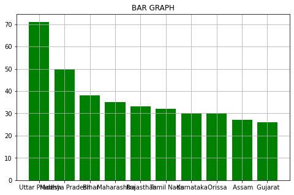

```python
plt.figure(figsize=(8,5))
plt.bar(list(data["State"].value_counts()[0:10].keys()),list(data["State"].value_counts()[0:10]),color='g')
plt.title('BAR GRAPH')
plt.grid(True)
plt.show()
```

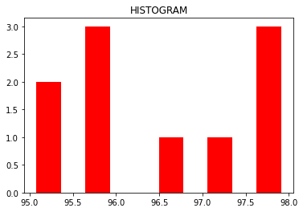

```python
plt.hist(Data['Literacy'],bins=10,color='r')
plt.title('HISTOGRAM')
plt.show()
```

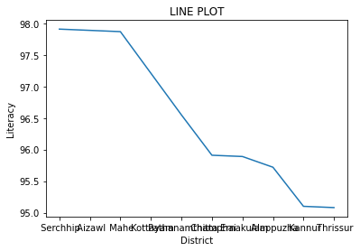

```python
sns.lineplot(data=Data,x='District',y='Literacy')
plt.title('LINE PLOT')
plt.show()
```

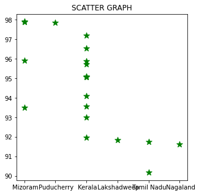

```python
plt.figure(figsize=(5,5))
plt.scatter(data=Data2,x='State',y='Literacy',marker='*',c='g',s=100)
plt.title('SCATTER GRAPH')
plt.show()
```

### SPLITTING THE DATA

```python
from sklearn import datasets
from sklearn.model_selection import train_test_split
import sklearn.model_selection as model_selection
```

```python
X=data.iloc[1:,0:2].values
```

```python
Y=data.iloc[1:,2]
```

```python
X_train,X_test,Y_train,Y_test=train_test_split(X,Y,test_size=0.2,random_state=1)
```

```python
X_train
```

```
array([[579, ' Champawat'],
       [249, ' Bagalkot'],
       [378, ' Sirsa'],
       ...,
       [564, ' Dimapur'],
       [17, ' Rangareddy'],
       [262, ' Akola']], dtype=object)
```

```python
X_test
```

```
array([[232, ' Jhansi'],
       [611, ' Lawngtlai'],
       [148, ' Maharajganj'],
       [97, ' Rae Bareli'],
       [337, ' Deoghar'],
       [559, ' Jaintia Hills'],
       [432, ' Mandla'],
       [143, ' Adilabad'],
       [394, ' Korba'],
       [542, ' Sirmaur'],
       [571, ' Debagarh'],
       [39, ' Bareilly'],
       [166, ' Bharatpur'],
       [293, ' Kishanganj'],
       [540, ' Dantewada'],
```

[output cut: 113 more lines]

```python
Y_train
```

```
578        Uttarakhand
248          Karnataka
377            Haryana
528            Gujarat
52        Chhattisgarh
            ...
15         West Bengal
358         Tamil Nadu
563           Nagaland
16      Andhra Pradesh
261        Maharashtra
Name: State, Length: 511, dtype: object
```

```python
Y_test
```

```
231     Uttar Pradesh
610           Mizoram
147     Uttar Pradesh
96      Uttar Pradesh
336         Jharkhand
            ...
586           Gujarat
86              Bihar
383             Assam
222       Maharashtra
135       Maharashtra
Name: State, Length: 128, dtype: object
```

### MACHINE LEARNING MODELS

```python
mat=pd.read_csv('C:/Users/SRAVYA/Downloads/student-mat-pass-or-fail.csv')
```

```python
mat.head()
```

|  | school | sex | age | address | famsize | Pstatus | Medu | Fedu | traveltime | studytime | ... | freetime | goout | Dalc | Walc | health | absences | G1 | G2 | G3 | pass |
| --- | --- | --- | --- | --- | --- | --- | --- | --- | --- | --- | --- | --- | --- | --- | --- | --- | --- | --- | --- | --- | --- |
| 0 | 1 | 1 | 18 | 1 | 0 | 0 | 4 | 4 | 2 | 2 | ... | 3 | 4 | 1 | 1 | 3 | 6 | 5 | 6 | 6 | 0 |
| 1 | 1 | 1 | 17 | 1 | 0 | 1 | 1 | 1 | 1 | 2 | ... | 3 | 3 | 1 | 1 | 3 | 4 | 5 | 5 | 6 | 0 |
| 2 | 1 | 1 | 15 | 1 | 1 | 1 | 1 | 1 | 1 | 2 | ... | 3 | 2 | 2 | 3 | 3 | 10 | 7 | 8 | 10 | 1 |
| 3 | 1 | 1 | 15 | 1 | 0 | 1 | 4 | 2 | 1 | 3 | ... | 2 | 2 | 1 | 1 | 5 | 2 | 15 | 14 | 15 | 1 |
| 4 | 1 | 1 | 16 | 1 | 0 | 1 | 3 | 3 | 1 | 2 | ... | 3 | 2 | 1 | 2 | 5 | 4 | 6 | 10 | 10 | 1 |

5 rows × 30 columns

```python
mat.tail()
```

|  | school | sex | age | address | famsize | Pstatus | Medu | Fedu | traveltime | studytime | ... | freetime | goout | Dalc | Walc | health | absences | G1 | G2 | G3 | pass |
| --- | --- | --- | --- | --- | --- | --- | --- | --- | --- | --- | --- | --- | --- | --- | --- | --- | --- | --- | --- | --- | --- |
| 390 | 0 | 0 | 20 | 1 | 1 | 0 | 2 | 2 | 1 | 2 | ... | 5 | 4 | 4 | 5 | 4 | 11 | 9 | 9 | 9 | 0 |
| 391 | 0 | 0 | 17 | 1 | 1 | 1 | 3 | 1 | 2 | 1 | ... | 4 | 5 | 3 | 4 | 2 | 3 | 14 | 16 | 16 | 1 |
| 392 | 0 | 0 | 21 | 0 | 0 | 1 | 1 | 1 | 1 | 1 | ... | 5 | 3 | 3 | 3 | 3 | 3 | 10 | 8 | 7 | 0 |
| 393 | 0 | 0 | 18 | 0 | 1 | 1 | 3 | 2 | 3 | 1 | ... | 4 | 1 | 3 | 4 | 5 | 0 | 11 | 12 | 10 | 1 |
| 394 | 0 | 0 | 19 | 1 | 1 | 1 | 1 | 1 | 1 | 1 | ... | 2 | 3 | 3 | 3 | 5 | 5 | 8 | 9 | 9 | 0 |

5 rows × 30 columns

```python
mat.shape
```

```
(395, 30)
```

```python
mat.describe()
```

|  | school | sex | age | address | famsize | Pstatus | Medu | Fedu | traveltime | studytime | ... | freetime | goout | Dalc | Walc | health | absences | G1 | G2 | G3 | pass |
| --- | --- | --- | --- | --- | --- | --- | --- | --- | --- | --- | --- | --- | --- | --- | --- | --- | --- | --- | --- | --- | --- |
| count | 395.000000 | 395.000000 | 395.000000 | 395.000000 | 395.000000 | 395.000000 | 395.000000 | 395.000000 | 395.000000 | 395.000000 | ... | 395.000000 | 395.000000 | 395.000000 | 395.000000 | 395.000000 | 395.000000 | 395.000000 | 395.000000 | 395.000000 | 395.000000 |
| mean | 0.883544 | 0.526582 | 16.696203 | 0.777215 | 0.288608 | 0.896203 | 2.749367 | 2.521519 | 1.448101 | 2.035443 | ... | 3.235443 | 3.108861 | 1.481013 | 2.291139 | 3.554430 | 5.708861 | 10.908861 | 10.713924 | 10.415190 | 0.670886 |
| std | 0.321177 | 0.499926 | 1.276043 | 0.416643 | 0.453690 | 0.305384 | 1.094735 | 1.088201 | 0.697505 | 0.839240 | ... | 0.998862 | 1.113278 | 0.890741 | 1.287897 | 1.390303 | 8.003096 | 3.319195 | 3.761505 | 4.581443 | 0.470487 |
| min | 0.000000 | 0.000000 | 15.000000 | 0.000000 | 0.000000 | 0.000000 | 0.000000 | 0.000000 | 1.000000 | 1.000000 | ... | 1.000000 | 1.000000 | 1.000000 | 1.000000 | 1.000000 | 0.000000 | 3.000000 | 0.000000 | 0.000000 | 0.000000 |
| 25% | 1.000000 | 0.000000 | 16.000000 | 1.000000 | 0.000000 | 1.000000 | 2.000000 | 2.000000 | 1.000000 | 1.000000 | ... | 3.000000 | 2.000000 | 1.000000 | 1.000000 | 3.000000 | 0.000000 | 8.000000 | 9.000000 | 8.000000 | 0.000000 |
| 50% | 1.000000 | 1.000000 | 17.000000 | 1.000000 | 0.000000 | 1.000000 | 3.000000 | 2.000000 | 1.000000 | 2.000000 | ... | 3.000000 | 3.000000 | 1.000000 | 2.000000 | 4.000000 | 4.000000 | 11.000000 | 11.000000 | 11.000000 | 1.000000 |
| 75% | 1.000000 | 1.000000 | 18.000000 | 1.000000 | 1.000000 | 1.000000 | 4.000000 | 3.000000 | 2.000000 | 2.000000 | ... | 4.000000 | 4.000000 | 2.000000 | 3.000000 | 5.000000 | 8.000000 | 13.000000 | 13.000000 | 14.000000 | 1.000000 |
| max | 1.000000 | 1.000000 | 22.000000 | 1.000000 | 1.000000 | 1.000000 | 4.000000 | 4.000000 | 4.000000 | 4.000000 | ... | 5.000000 | 5.000000 | 5.000000 | 5.000000 | 5.000000 | 75.000000 | 19.000000 | 19.000000 | 20.000000 | 1.000000 |

8 rows × 30 columns

```python
mat.isnull().any()
```

```
school        False
sex           False
age           False
address       False
famsize       False
Pstatus       False
Medu          False
Fedu          False
traveltime    False
studytime     False
failures      False
schoolsup     False
famsup        False
paid          False
activities    False
nursery       False
higher        False
internet      False
romantic      False
famrel        False
freetime      False
goout         False
Dalc          False
Walc          False
health        False
absences      False
G1            False
G2            False
G3            False
pass          False
dtype: bool
```

```python
mat.drop('Walc',axis=1,inplace=True)
```

```python
mat.drop('Pstatus',axis=1,inplace=True)
```

```python
mat.drop('Fedu',axis=1,inplace=True)
```

```python
mat.drop('Medu',axis=1,inplace=True)
```

```python
mat.drop('paid',axis=1,inplace=True)
```

```python
mat.drop('activities',axis=1,inplace=True)
```

```python
mat.drop('internet',axis=1,inplace=True)
```

```python
mat.drop('romantic',axis=1,inplace=True)
```

```python
mat.drop('famrel',axis=1,inplace=True)
```

```python
mat.drop('famsup',axis=1,inplace=True)
```

```python
mat.drop('schoolsup',axis=1,inplace=True)
```

```python
mat
```

|  | school | sex | age | address | famsize | traveltime | studytime | failures | nursery | higher | freetime | goout | Dalc | health | absences | G1 | G2 | G3 | pass |
| --- | --- | --- | --- | --- | --- | --- | --- | --- | --- | --- | --- | --- | --- | --- | --- | --- | --- | --- | --- |
| 0 | 1 | 1 | 18 | 1 | 0 | 2 | 2 | 0 | 1 | 1 | 3 | 4 | 1 | 3 | 6 | 5 | 6 | 6 | 0 |
| 1 | 1 | 1 | 17 | 1 | 0 | 1 | 2 | 0 | 0 | 1 | 3 | 3 | 1 | 3 | 4 | 5 | 5 | 6 | 0 |
| 2 | 1 | 1 | 15 | 1 | 1 | 1 | 2 | 3 | 1 | 1 | 3 | 2 | 2 | 3 | 10 | 7 | 8 | 10 | 1 |
| 3 | 1 | 1 | 15 | 1 | 0 | 1 | 3 | 0 | 1 | 1 | 2 | 2 | 1 | 5 | 2 | 15 | 14 | 15 | 1 |
| 4 | 1 | 1 | 16 | 1 | 0 | 1 | 2 | 0 | 1 | 1 | 3 | 2 | 1 | 5 | 4 | 6 | 10 | 10 | 1 |
| ... | ... | ... | ... | ... | ... | ... | ... | ... | ... | ... | ... | ... | ... | ... | ... | ... | ... | ... | ... |
| 390 | 0 | 0 | 20 | 1 | 1 | 1 | 2 | 2 | 1 | 1 | 5 | 4 | 4 | 4 | 11 | 9 | 9 | 9 | 0 |
| 391 | 0 | 0 | 17 | 1 | 1 | 2 | 1 | 0 | 0 | 1 | 4 | 5 | 3 | 2 | 3 | 14 | 16 | 16 | 1 |
| 392 | 0 | 0 | 21 | 0 | 0 | 1 | 1 | 3 | 0 | 1 | 5 | 3 | 3 | 3 | 3 | 10 | 8 | 7 | 0 |
| 393 | 0 | 0 | 18 | 0 | 1 | 3 | 1 | 0 | 0 | 1 | 4 | 1 | 3 | 5 | 0 | 11 | 12 | 10 | 1 |
| 394 | 0 | 0 | 19 | 1 | 1 | 1 | 1 | 0 | 1 | 1 | 2 | 3 | 3 | 5 | 5 | 8 | 9 | 9 | 0 |

395 rows × 19 columns

### SPLITTING

```python
x=mat.iloc[1:,15:18].values
```

```python
print(x)
print(y)
```

[output not shown]

```python
y=mat.iloc[1:,18]
```

```python
x_train,x_test,y_train,y_test=train_test_split(x,y,test_size=0.2,random_state=2)
```

### LOGISTIC REGRESSION INCLUDING FITTING,PREDICTION,ACCURACY

```python
from sklearn.linear_model import LogisticRegression
```

```python
lr=LogisticRegression()
lr.fit(x_train,y_train)
```

```
LogisticRegression()
```

```python
y_pred=lr.predict(x_test)
```

```python
from sklearn.metrics import confusion_matrix,classification_report,accuracy_score
```

```python
confusion_matrix(y_test,y_pred)
```

```
array([[21,  0],
       [ 0, 58]], dtype=int64)
```

```python
print(lr.score(x_test,y_test))
```

```
1.0
```

### DECISION TREE CLASSIFIER INCLUDING FITTING,PREDICTION,ACCURACY

```python
from sklearn.tree import DecisionTreeClassifier
```

```python
dtc=DecisionTreeClassifier()
```

```python
dtc.fit(x_train,y_train)
```

```
DecisionTreeClassifier()
```

```python
y_pred=dtc.predict(x_test)
```

```python
y_test.head(),y_pred[0:5]
```

```
(95     1
 33     1
 223    1
 316    0
 351    1
 Name: pass, dtype: int64,
 array([1, 1, 1, 0, 1], dtype=int64))
```

```python
accuracy_score(y_test,y_pred)
```

```
1.0
```

### LINEAR REGRESSION INCLUDING FITTING,PREDICTION,ACCURACY

```python
from sklearn.linear_model import LinearRegression
```

```python
lr2=LinearRegression()
```

```python
lr2.fit(x_train,y_train)
```

```
LinearRegression()
```

```python
y_pred=lr2.predict(x_test)
```

```python
print(x_test)
print(y_pred)
```

```
[[ 7 10 10]
 [ 8 10 12]
 [12 13 13]
 [ 8  8  0]
 [13 13 13]
 [12 12 11]
 [ 8  9  8]
 [14 14 14]
 [17 15 15]
 [13 13 14]
 [ 6  5  6]
 [ 8  8 10]
 [12 13 12]
 [13 13 11]
 [14 14 13]
 [16 17 17]
 [ 6  0  0]
 [15 14 15]
 [ 7  0  0]
 [15 14 15]
 [13 12 12]
 [13 12 12]
 [ 7  9  8]
 [11 12 10]
 [10 10 10]
 [ 8 10 10]
 [12 15 15]
 [10 11  9]
 [ 8  9 10]
 [16 15 15]
 [14 15 15]
 [11 11 11]
 [ 6  9  8]
 [13 12 12]
 [16 18 19]
 [13 10 11]
 [ 9  9  9]
 [10 13 13]
 [10 12 11]
 [11 11 11]
```

[output cut: 38 more lines]

```
 [13 11 11]]
[ 0.57925335  0.71547569  0.87451903 -0.05167779  0.88781527  0.73679449
  0.45482505  0.97737301  1.09352322  0.94927832  0.24611269  0.5629527
  0.81305598  0.76488917  0.91590996  1.23274997 -0.19665783  1.0521323
 -0.18336159  1.0521323   0.81155378  0.81155378  0.44152881  0.6620352
  0.61914207  0.59254959  1.02704202  0.57247747  0.57775115  1.08022698
  1.0536345   0.70869981  0.42823257  0.81155378  1.37047451  0.72049384
  0.52958434  0.84792655  0.71020201  0.70869981  0.59104739  0.96407677
  1.23274997  1.12839379  0.68210732  0.96107236  0.57775115  0.85972059
  1.08022698  0.93598208  0.69540356  0.90111151 -0.06647624  0.88631307
  1.10180131  1.15648848 -0.09457092 -0.10936937  0.84642435  1.23124777
 -0.11688038  0.63243831  0.70869981  0.13798504  0.35347328  0.52808213
  0.18464964  0.45332284  1.04033826  0.99066925  1.15648848  1.3223077
  1.34890018  0.50148965  0.46812129  1.06693074 -0.12266561  0.82635222
  0.73529229]
```

```python
print(lr2.score(x_test,y_test))
```

```
0.6239474407477752
```

### A BRIEF DESCRIPTION

```
 Literacy in India is a key for socio-economic progress. Despite government programmes, India's literacy rate increased only "sluggishly".The 2011 census, indicated a 2001–2011 decadal literacy growth of 9.2%, which is slower than the growth seen during the previous decade. An old analytical 1990 study estimated that it would take until 2060 for India to achieve universal literacy at then-current rate of progress.Census of India pegged average literacy rate to be 73% in 2011 while National Statistical Commission surveyed literacy to be 77.7% in 2017–18.
  In this project,we implemented EXPLORATORY DATA ANALYSIS,SPLITTING BY USING SKLEARN,APPLYING 3 MACHINE LEARNIG MODELS....
```

1.EXPLORATORY DATA ANALYSIS: In statistics, exploratory data analysis is an approach of analyzing data sets to summarize their main characteristics, often using statistical graphics and other data visualization methods. A statistical model can be used or not, but primarily EDA is for seeing what the data can tell us beyond the formal modeling or hypothesis testing task. Exploratory data analysis was promoted by John Tukey to encourage statisticians to explore the data, and possibly formulate hypotheses that could lead to new data collection and experiments. EDA is different from initial data analysis (IDA), which focuses more narrowly on checking assumptions required for model fitting and hypothesis testing, and handling missing values and making transformations of variables as needed. EDA encompasses IDA.

A data source is where that data that is being used to run a report or gain information is originating from. Data cleaning, or cleansing, is the process of correcting and deleting inaccurate records from a database or table. Data visualization is the process of translating large data sets and metrics into charts, graphs and other visuals.

2.SPLITTING THE DATA: To train any machine learning model irrespective what type of dataset is being used you have to split the dataset into training data and testing data. Here I have used the ‘train_test_split’ to split the data in 80:20 ratio i.e. 80% of the data will be used for training the model while 20% will be used for testing the model that is built out of it.

3.MACHINE LEARNING MODELS: All machine learning models are categorized as either supervised or unsupervised. If the model is a supervised model, it’s then sub-categorized as either a regression or classification model.

```
   Here we used 3 machine learning models.
           1.LOGISTIC REGRESSION
           2.DECISION TREE CLASSIFIER
           3.LINEAR REGRESSION
```

->Logistic regression is a statistical analysis method used to predict a data value based on prior observations of a data set.

->Decision Tree is a Supervised learning technique that can be used for both classification and Regression problems, but mostly it is preferred for solving Classification problems.

->Linear Regression Algorithm is a machine learning algorithm based on supervised learning.

[output not shown]